# Penguin Size Data Subset - Adjusted Scatterplot

Andrew Heneghan

2/21/2023

```r
penguins <- na.omit(read.csv(file="https://raw.githubusercontent.com/azheneghan/aheneghan/main/datasets/w03-penguins.csv"))
penguin.subset <- penguins %>%
  mutate(BMI = body_mass_g / 4000) %>%
  filter(body_mass_g > 3500, body_mass_g < 5000, species != "Chinstrap", island != "Dream") %>%
  dplyr::select(species, island, bill_length_mm, bill_depth_mm, flipper_length_mm, BMI)
bill.length = penguin.subset$bill_length_mm
flipper.length = penguin.subset$flipper_length_mm
body.mass = penguin.subset$BMI
pspecies = penguin.subset$species
adelie.id = which(pspecies=="Adelie")
gentoo.id = which(pspecies=="Gentoo")
```

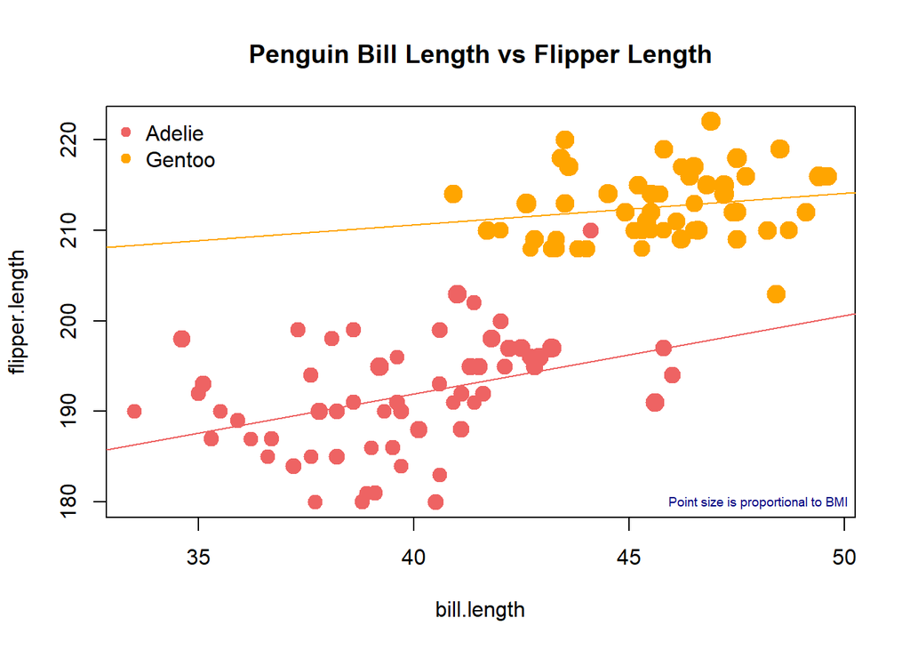

```r
plot(bill.length, flipper.length, main = "Penguin Bill Length vs Flipper Length", type = "n")
points(bill.length[adelie.id], flipper.length[adelie.id],
       pch = 19, col = "indianred2", cex = 2*(body.mass/max(body.mass))[adelie.id], alpha = 0.6)
points(bill.length[gentoo.id], flipper.length[gentoo.id],
       pch = 19, col = "orange", cex = 2*(body.mass/max(body.mass))[gentoo.id], alpha = 0.6)
legend("topleft", c("Adelie", "Gentoo"),
                  col=c("indianred2", "orange"),
                  pch=c(19, 19),
                  bty = "n")
abline(lm(flipper.length[adelie.id] ~ bill.length[adelie.id]), col = "indianred2")
abline(lm(flipper.length[gentoo.id] ~ bill.length[gentoo.id]), col = "orange")
text(48, 180, "Point size is proportional to BMI", col = "navyblue", cex = 0.6)
```

This scatterplot was made to look at the relationship between changes observed in bill length and flipper length (both in millimeters) of adult foraging penguins near Palmer Station, Antarctica. The data was subsetted before constructing the scatterplot. Only observations for the Adelie and Gentoo species of penguin from the Biscoe and Torgersen islands, with body masses between 3500 and 5000 grams, are considered. Observations with missing values are not included either. The two separate colors of the points represent the species of penguin each individual penguin belongs to. The size of the data points represent the body mass index (body mass divided by 4000, in grams) of the individual penguins. Overall, it appeared that bill and flipper lengths (in millimeters) have positive linear relationships for both species. As bill length of a penguin increases, their flipper length will increase as well. It seems the Gentoo species tends to have larger body mass indexes, longer bill lengths, and longer flipper lengths compared to the Adelie species. Although, some of the Adelie penguins appear to have bill lengths similar to the average bill length of the Gentoo species.